# Karls_data

## Interaction：Treatment × Sex → AF

We also examine whether the effect of treatment on AF differs by sex, which would indicate a treatment-sex interaction.

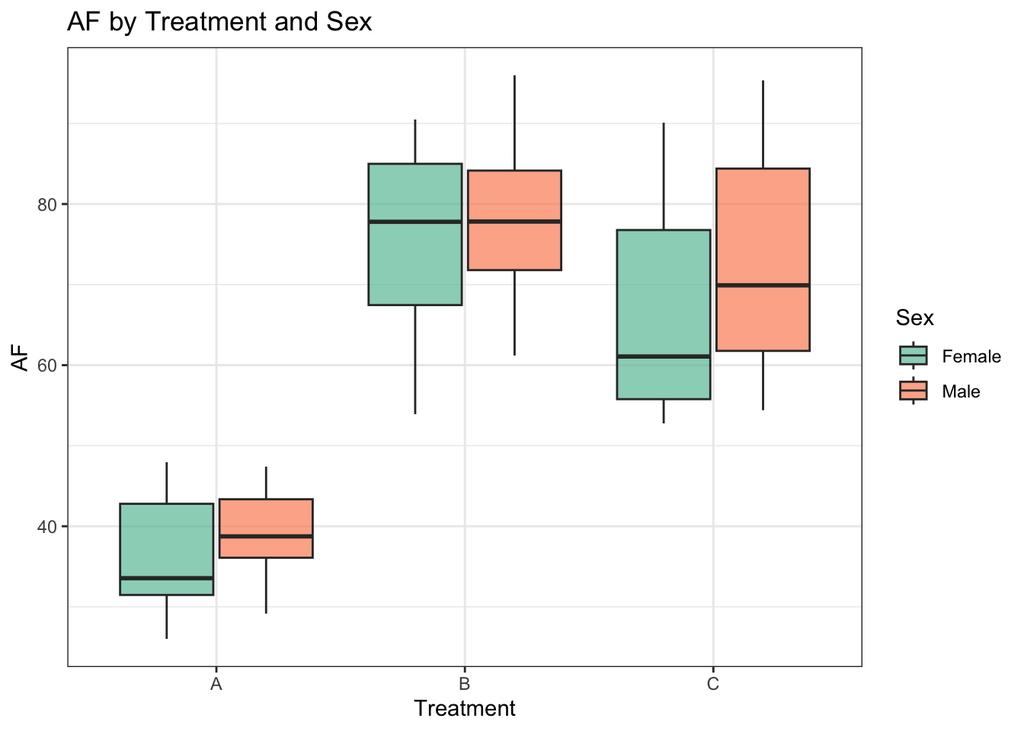

AF by treatment group, stratified by sex.

```r
ggplot(df, aes(x = treatment, y = AF, fill = sex)) +
  geom_boxplot(alpha = 0.7, position = position_dodge(0.8)) +
  scale_fill_brewer(palette = "Set2") +
  labs(title = "AF by Treatment and Sex", x = "Treatment", y = "AF",
       fill = "Sex") +
  theme_bw()
```

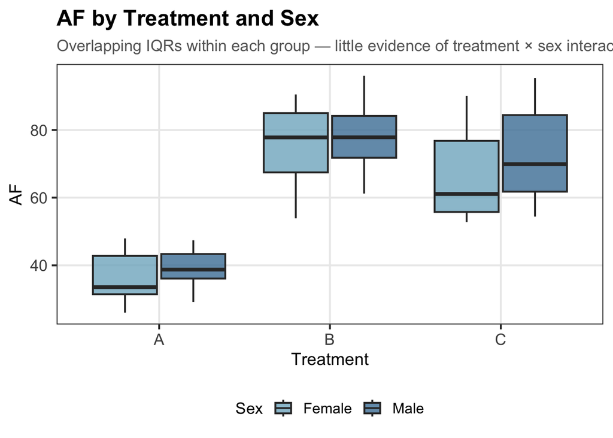

```r
ggplot(df, aes(x = treatment, y = AF, fill = sex)) +
  geom_boxplot(alpha = 0.8, position = position_dodge(0.8)) +
  scale_fill_manual(values = c(Female = "#7FB3C8", Male = "#4A7FA5")) +
  labs(title = "AF by Treatment and Sex",
       subtitle = "Overlapping IQRs within each group — little evidence of treatment × sex interaction",
       x = "Treatment", y = "AF", fill = "Sex") +
  theme_ppt
```

```r
save_ppt_fig("ppt_af_treatment_by_sex.png", width = 9, height = 6)
```

Within each treatment group, AF distributions are largely similar between females and males, with overlapping interquartile ranges across all three groups. The dominant pattern remains the treatment effect — group A has substantially lower AF than groups B and C regardless of sex. There is a slight tendency for males to have marginally higher AF in groups A and C, but the overlap is considerable and this difference appears negligible. Overall, there is little evidence of a treatment-sex interaction, suggesting that the effect of treatment on AF does not differ meaningfully between females and males.

# Models

Based on EDA findings, 2 separate models are fitted to address the 2 outcomes of interest:

1. **AF (continuous): multiple linear regression**

AF is a continuous outcome with no natural upper or lower bound in the context of this study. Linear regression is the appropriate choice because it models the expected value of a continuous response as a linear combination of predictors, and the EDA showed that AF follows a roughly symmetric distribution within each treatment group with no severe skew. The model estimates how much AF changes, on average, for a one-unit change in each predictor — making the coefficients directly interpretable as differences in AF values.

2. **PR (binary): logistic regression**

PR is a binary outcome: each participant either had a positive response (yes) or did not (no). Standard linear regression is unsuitable here because it can produce predicted probabilities outside the range [0, 1] and assumes a linear relationship between predictors and the outcome on the raw scale. Logistic regression instead models the log-odds of PR = yes as a linear function of the predictors, which guarantees that all predicted probabilities fall between 0 and 1. Coefficients are exponentiated to produce odds ratios, which express how the odds of a positive response change with each predictor.

Further details on model selection and interpretation are provided in the subsections below.

Both models follow the same structure: a baseline model with treatment only, followed by a main-effects model adding age and sex as covariates, and finally a SNP-augmented model incorporating the top genetic candidates identified during EDA. Smoking status and `rs123456` are excluded from all models as zero-variance variables.

## · Choose SNP candidates

As a general rule of thumb, reliable regression estimates require limited observations per predictor, including all 51 SNPs at once would far exceed this limit, leading to unstable and unreliable coefficient estimates. Therefore, univariable regression is used at the screening stage — rather than correlation alone — because it places each SNP on the same inferential scale as the final model, producing a p-value that reflects the significance of the SNP–outcome association under the same modelling framework.

For each of the 50 SNPs, a separate regression is fitted with just that SNP as the sole predictor, one at a time.

- For AF, linear regression is used;
- for PR, logistic regression.

This gives a p-value for each SNP indicating whether it has a statistically significant association with the outcome on its own.

Two thresholds are checked:

- the stricter **Bonferroni threshold** (0.05 / 50 = 0.001), which accounts for the fact that we are running 50 tests at once and would expect some false positives by chance, and
- the more lenient **nominal threshold** (p < 0.05).

SNPs passing the nominal threshold are taken forward into the multivariable models. If few or no SNPs survive the stricter Bonferroni correction, which is expected given the small sample size, the nominal threshold is used instead, and any SNP findings are treated as preliminary rather than definitive.

```r
snp_cols_model <- names(df)[str_detect(names(df), "^rs") & names(df) != "rs123456"]

# AF: univariable linear regression for each SNP
snp_screen_af <- tibble(
  SNP  = snp_cols_model,
  p    = sapply(snp_cols_model, function(s) {
    summary(lm(AF ~ as.numeric(df[[s]]), data = df))$coefficients[2, 4]
  }),
  beta = sapply(snp_cols_model, function(s) {
    coef(lm(AF ~ as.numeric(df[[s]]), data = df))[2]
  })
) |>
  arrange(p) |>
  mutate(bonferroni = p < 0.05 / n(),          # Bonferroni-corrected threshold
         nominal    = p < 0.05)

cat("SNPs passing Bonferroni threshold (AF):", sum(snp_screen_af$bonferroni), "\n")
```

```
## SNPs passing Bonferroni threshold (AF): 0
```

```r
cat("SNPs passing nominal p < 0.05 (AF):",    sum(snp_screen_af$nominal),    "\n")
```

```
## SNPs passing nominal p < 0.05 (AF): 1
```

```r
print(head(snp_screen_af, 10))
```

```
## # A tibble: 10 × 5
##    SNP          p  beta bonferroni nominal
##    <chr>    <dbl> <dbl> <lgl>      <lgl>
##  1 rs19486 0.0149 -6.23 FALSE      TRUE
##  2 rs26922 0.0529 -5.48 FALSE      FALSE
##  3 rs31247 0.0803 -4.63 FALSE      FALSE
##  4 rs88128 0.114   4.26 FALSE      FALSE
##  5 rs67611 0.130  -4.19 FALSE      FALSE
##  6 rs91479 0.142  -3.86 FALSE      FALSE
##  7 rs59798 0.215   3.27 FALSE      FALSE
##  8 rs31255 0.230   3.70 FALSE      FALSE
##  9 rs15488 0.245   3.24 FALSE      FALSE
## 10 rs36733 0.278  -3.08 FALSE      FALSE
```

```r
# PR: univariable logistic regression for each SNP
pr_num <- as.numeric(df$PR) - 1   # recode to 0/1

snp_screen_pr <- tibble(
  SNP  = snp_cols_model,
  p    = sapply(snp_cols_model, function(s) {
    summary(glm(pr_num ~ as.numeric(df[[s]]),
                family = binomial))$coefficients[2, 4]
  }),
  OR   = sapply(snp_cols_model, function(s) {
    exp(coef(glm(pr_num ~ as.numeric(df[[s]]),
                 family = binomial))[2])
  })
) |>
  arrange(p) |>
  mutate(bonferroni = p < 0.05 / n(),
         nominal    = p < 0.05)

cat("\nSNPs passing Bonferroni threshold (PR):", sum(snp_screen_pr$bonferroni), "\n")
```

```
##
## SNPs passing Bonferroni threshold (PR): 0
```

```r
cat("SNPs passing nominal p < 0.05 (PR):",    sum(snp_screen_pr$nominal),    "\n")
```

```
## SNPs passing nominal p < 0.05 (PR): 1
```

```r
print(head(snp_screen_pr, 10))
```

```
## # A tibble: 10 × 5
##    SNP          p    OR bonferroni nominal
##    <chr>    <dbl> <dbl> <lgl>      <lgl>
##  1 rs91154 0.0101 0.438 FALSE      TRUE
##  2 rs58943 0.0562 0.577 FALSE      FALSE
##  3 rs57586 0.0929 0.613 FALSE      FALSE
##  4 rs29978 0.0949 0.614 FALSE      FALSE
##  5 rs87926 0.110  0.584 FALSE      FALSE
##  6 rs69792 0.113  0.648 FALSE      FALSE
##  7 rs13977 0.162  0.667 FALSE      FALSE
##  8 rs59119 0.163  0.668 FALSE      FALSE
##  9 rs35374 0.170  0.678 FALSE      FALSE
## 10 rs78356 0.182  1.44  FALSE      FALSE
```

No SNPs passed the Bonferroni-corrected threshold for either outcome, which is unsurprising given the small sample size of 100 participants.

```r
# Retain SNPs that pass the nominal threshold (p < 0.05) for inclusion in the augmented models. Since none pass Bonferroni, we use nominal significance and note this as exploratory.
top_snps_af <- snp_screen_af |> filter(nominal) |> pull(SNP)
top_snps_pr <- snp_screen_pr |> filter(nominal) |> pull(SNP)

cat("Top AF SNP candidates:", paste(top_snps_af, collapse = ", "), "\n")
```

```
## Top AF SNP candidates: rs19486
```

```r
cat("Top PR SNP candidates:", paste(top_snps_pr, collapse = ", "), "\n")
```

```
## Top PR SNP candidates: rs91154
```

For AF, one SNP passed the nominal threshold: **rs19486** (p = 0.015, β = −6.23), indicating that each additional alternate allele is associated with a decrease of 6.23 units in AF on average.

For PR, one SNP passed the nominal threshold: **rs91154** (p = 0.010, OR = 0.438), suggesting that each additional alternate allele is associated with lower odds of a positive response.

Both findings are consistent with the EDA results observed earlier. These two SNPs are carried forward as candidates into the multivariable models, and their effects should be interpreted as exploratory given that they did not survive Bonferroni correction.

## · AF model

Three linear regression models are fitted for AF, each building on the previous one.

1. The **baseline model** includes treatment only, to capture the raw treatment effect seen in the EDA.
2. The **main effects model** adds age and sex as covariates, allowing us to estimate the treatment effect after accounting for any differences in participant characteristics across groups.
3. The **third model** further adds rs19486, the one SNP that passed the nominal screening threshold, to assess whether genetic variation explains any additional variation in AF beyond treatment, age, and sex.

Comparing these three models allows us to see how much each additional set of variables improves the fit, and whether the treatment effect changes once other factors are accounted for.

```r
df_model <- df |> drop_na(age)   # Remove NA rows in Age

# Model 0: intercept only (for reference R²)
lm_af_null <- lm(AF ~ 1, data = df_model)
cat("Model 0: Intercept only\n")
```

```
## Model 0: Intercept only
```

```r
print(lm_af_null)
```

```
##
## Call:
## lm(formula = AF ~ 1, data = df_model)
##
## Coefficients:
## (Intercept)
##       60.73
```

```r
# Model 1: treatment only
lm_af_base <- lm(AF ~ treatment, data = df_model)
cat("-------\n")
cat("Model 1: Treatment only\n")
```

```
## Model 1: Treatment only
```

```r
print(lm_af_base)
```

```
##
## Call:
## lm(formula = AF ~ treatment, data = df_model)
##
## Coefficients:
## (Intercept)   treatmentB   treatmentC
##       37.53        38.91        31.16
```

```r
# Model 2: treatment + age + sex
lm_af_main <- lm(AF ~ treatment + age + sex, data = df_model)
cat("-------\n")
cat("Model 2: Treatment + age + sex\n")
```

```
## Model 2: Treatment + age + sex
```

```r
print(lm_af_main)
```

```
##
## Call:
## lm(formula = AF ~ treatment + age + sex, data = df_model)
##
## Coefficients:
## (Intercept)   treatmentB   treatmentC          age      sexMale
##    -19.5458      35.7223      34.3395       1.6509       0.7092
```

```r
# Model 3: treatment + age + sex + top SNP candidates
# Build the formula dynamically from the screened candidates
if (length(top_snps_af) > 0) {
  snp_terms_af <- paste(
    sprintf("as.numeric(%s)", top_snps_af),
    collapse = " + "
  )
  lm_af_snp <- lm(
    as.formula(paste("AF ~ treatment + age + sex +", snp_terms_af)),
    data = df
  )
  cat("-------\n")
  cat("Model 3: Treatment + age + sex +", paste(top_snps_af, collapse = ", "), "\n")
} else {
  lm_af_snp <- lm_af_main
  cat("-------\n")
  cat("Model 3: No SNPs passed nominal screening — falling back to Model 2\n")
}
```

```
## -------
## Model 3: Treatment + age + sex + rs19486
```

```r
print(lm_af_snp)
```

```
##
## Call:
## lm(formula = as.formula(paste("AF ~ treatment + age + sex +",
##     snp_terms_af)), data = df)
##
## Coefficients:
##         (Intercept)           treatmentB           treatmentC
##            -20.1917              35.8525              34.4570
##                 age              sexMale  as.numeric(rs19486)
##              1.6520               0.7287               0.2628
```

**Model 2 (Treatment + age + sex)** retains the large treatment effects after adjusting for age and sex, with B and C remaining 35.72 and 34.34 units above A respectively. Age has a positive association with AF (β = 1.65), meaning each additional year of age is associated with an increase of 1.65 units in AF on average. Sex has a negligible effect (β = 0.71).

**Model 3 (Treatment + age + sex + rs19486)** produces very similar coefficient estimates to Model 2, with rs19486 contributing a near-zero additional effect (β = 0.26). This suggests that rs19486 adds little explanatory value for AF beyond the other predictors already in the model, despite passing the nominal screening threshold.

## · PR model

Three logistic regression models are fitted for PR, following the same structure as the AF models.

1. The **baseline model** includes treatment only, to capture the raw association between treatment group and the probability of a positive response.
2. The **main effects model** adds age and sex, given that the EDA showed a strong association between age and PR outcome.
3. The **third model** further adds rs91154, the one SNP that passed the nominal screening threshold for PR, to assess whether it explains any additional variation in the probability of a positive response beyond treatment, age, and sex.

```r
# Model 1: treatment only
glm_pr_base <- glm(PR ~ treatment, data = df_model, family = binomial)
cat("Model 1: Treatment only\n")
```

```
## Model 1: Treatment only
```

```r
print(glm_pr_base)
```

```
##
## Call:  glm(formula = PR ~ treatment, family = binomial, data = df_model)
##
## Coefficients:
## (Intercept)   treatmentB   treatmentC
##      0.1252       0.4626      -0.5526
##
## Degrees of Freedom: 97 Total (i.e. Null);  95 Residual
## Null Deviance:       135.8
## Residual Deviance: 131.7     AIC: 137.7
```

```r
# Model 2: treatment + age + sex
glm_pr_main <- glm(PR ~ treatment + age + sex, data = df_model, family = binomial)
cat("-------\n")
cat("Model 2: Treatment + age + sex\n")
```

```
## Model 2: Treatment + age + sex
```

```r
print(glm_pr_main)
```

```
##
## Call:  glm(formula = PR ~ treatment + age + sex, family = binomial,
##     data = df_model)
##
## Coefficients:
## (Intercept)   treatmentB   treatmentC          age      sexMale
##    -8.45159     -0.02503     -0.33614      0.26444     -0.71707
##
## Degrees of Freedom: 97 Total (i.e. Null);  93 Residual
## Null Deviance:       135.8
## Residual Deviance: 93.86     AIC: 103.9
```

```r
# Model 3: treatment + age + sex + top SNP candidates
if (length(top_snps_pr) > 0) {
  snp_terms_pr <- paste(
    sprintf("as.numeric(%s)", top_snps_pr),
    collapse = " + "
  )
  glm_pr_snp <- glm(
    as.formula(paste("PR ~ treatment + age + sex +", snp_terms_pr)),
    data   = df,
    family = binomial
  )
  cat("-------\n")
  cat("Model 3: Treatment + age + sex +", paste(top_snps_pr, collapse = ", "), "\n")
} else {
  glm_pr_snp <- glm_pr_main
  cat("-------\n")
  cat("Model 3: No SNPs passed nominal screening — falling back to Model 2\n")
}
```

```
## -------
## Model 3: Treatment + age + sex + rs91154
```

```r
print(glm_pr_snp)
```

```
##
## Call:  glm(formula = as.formula(paste("PR ~ treatment + age + sex +",
##     snp_terms_pr)), family = binomial, data = df)
##
## Coefficients:
##         (Intercept)           treatmentB           treatmentC
##            -7.08397              0.02857             -0.19048
##                 age              sexMale  as.numeric(rs91154)
##             0.26222             -0.63871             -0.71020
##
## Degrees of Freedom: 97 Total (i.e. Null);  92 Residual
##   (2 observations deleted due to missingness)
## Null Deviance:       135.8
## Residual Deviance: 90.59     AIC: 102.6
```

**Model 3 (Treatment + age + sex + rs91154)** shows a further modest improvement in fit (AIC: 102.6 vs 103.9). rs91154 has a negative coefficient (β = −0.71), indicating that each additional alternate allele is associated with lower log-odds of PR, consistent with the EDA screening result. The treatment and age coefficients remain largely unchanged from Model 2, suggesting rs91154 contributes some independent explanatory value for PR.

# Explore models / interpret models

## · AF model

```r
# Compare models using AIC and adjusted R²
model_compare_af <- tibble(
  Model       = c("Null", "Treatment only", "Main effects", "Main + SNPs"),
  AIC         = c(AIC(lm_af_null), AIC(lm_af_base),
                  AIC(lm_af_main), AIC(lm_af_snp)),
  Adj_R2      = c(
    summary(lm_af_null)$adj.r.squared,
    summary(lm_af_base)$adj.r.squared,
    summary(lm_af_main)$adj.r.squared,
    summary(lm_af_snp)$adj.r.squared
  )
) |>
  mutate(across(where(is.numeric), ~ round(.x, 3)))

print(model_compare_af)
```

```
## # A tibble: 4 × 3
##   Model            AIC Adj_R2
##   <chr>          <dbl>  <dbl>
## 1 Null            864.  0
## 2 Treatment only  745.  0.709
## 3 Main effects    498.  0.977
## 4 Main + SNPs     500.  0.977
```

```r
# ANOVA to formally test whether adding covariates improves fit
anova(lm_af_base, lm_af_main, lm_af_snp)
```

```
## Analysis of Variance Table
##
## Model 1: AF ~ treatment
## Model 2: AF ~ treatment + age + sex
## Model 3: AF ~ treatment + age + sex + as.numeric(rs19486)
##   Res.Df     RSS Df Sum of Sq        F Pr(>F)
## 1     95 10572.0
## 2     93   819.4  2    9752.6 549.9203 <2e-16 ***
## 3     92   815.8  1       3.6   0.4052  0.526
## ---
## Signif. codes:  0 '***' 0.001 '**' 0.01 '*' 0.05 '.' 0.1 ' ' 1
```

```r
# Full summary of the selected main-effects model
summary(lm_af_main)
```

```
##
## Call:
## lm(formula = AF ~ treatment + age + sex, data = df_model)
##
## Residuals:
##     Min      1Q  Median      3Q     Max
## -6.7894 -1.8238  0.2285  1.6908  7.4906
##
## Coefficients:
##              Estimate Std. Error t value Pr(>|t|)
## (Intercept) -19.54577    1.79697 -10.877   <2e-16 ***
## treatmentB   35.72233    0.77907  45.853   <2e-16 ***
## treatmentC   34.33947    0.71886  47.770   <2e-16 ***
## age           1.65092    0.05118  32.254   <2e-16 ***
## sexMale       0.70920    0.61609   1.151    0.253
## ---
## Signif. codes:  0 '***' 0.001 '**' 0.01 '*' 0.05 '.' 0.1 ' ' 1
##
## Residual standard error: 2.968 on 93 degrees of freedom
## Multiple R-squared:  0.9779, Adjusted R-squared:  0.977
## F-statistic:  1030 on 4 and 93 DF,  p-value: < 2.2e-16
```

```r
# 95% confidence intervals for all coefficients
confint(lm_af_main)
```

```
##                   2.5 %     97.5 %
## (Intercept) -23.1141880 -15.977343
## treatmentB   34.1752493  37.269407
## treatmentC   32.9119678  35.766979
## age           1.5492755   1.752559
## sexMale      -0.5142351   1.932637
```

After adjusting for age and sex, treatment B and C are associated with AF values approximately 35.7 and 34.3 units higher than A respectively (both p < 0.001). Each additional year of age increases AF by ~1.65 units (p < 0.001). Sex has no meaningful effect as we expected. The model explains 97.7% of variance in AF.

## · PR model

```r
# Compare models using AIC and McFadden's pseudo-R²
mcfadden_r2 <- function(model) {
  1 - (logLik(model) / logLik(update(model, . ~ 1)))
}

model_compare_pr <- tibble(
  Model        = c("Treatment only", "Main effects", "Main + SNPs"),
  AIC          = c(AIC(glm_pr_base), AIC(glm_pr_main), AIC(glm_pr_snp)),
  McFadden_R2  = c(
    as.numeric(mcfadden_r2(glm_pr_base)),
    as.numeric(mcfadden_r2(glm_pr_main)),
    as.numeric(mcfadden_r2(glm_pr_snp))
  )
) |>
  mutate(across(where(is.numeric), ~ round(.x, 3)))

print(model_compare_pr)
```

```
## # A tibble: 3 × 3
##   Model            AIC McFadden_R2
##   <chr>          <dbl>       <dbl>
## 1 Treatment only  138.       0.03
## 2 Main effects    104.       0.309
## 3 Main + SNPs     103.       0.346
```

```r
# Likelihood ratio test
anova(glm_pr_base, glm_pr_main, glm_pr_snp, test = "LRT")
```

```
## Analysis of Deviance Table
##
## Model 1: PR ~ treatment
## Model 2: PR ~ treatment + age + sex
## Model 3: PR ~ treatment + age + sex + as.numeric(rs91154)
##   Resid. Df Resid. Dev Df Deviance Pr(>Chi)
## 1        95    131.717
## 2        93     93.857  2   37.860 6.01e-09 ***
## 3        92     90.593  1    3.264  0.07082 .
## ---
## Signif. codes:  0 '***' 0.001 '**' 0.01 '*' 0.05 '.' 0.1 ' ' 1
```

```r
# Full summary of the selected main-effects model
summary(glm_pr_main)
```

```
##
## Call:
## glm(formula = PR ~ treatment + age + sex, family = binomial,
##     data = df_model)
##
## Coefficients:
##             Estimate Std. Error z value Pr(>|z|)
## (Intercept) -8.45159    1.74401  -4.846 1.26e-06 ***
## treatmentB  -0.02503    0.65389  -0.038    0.969
## treatmentC  -0.33614    0.60809  -0.553    0.580
## age          0.26444    0.05281   5.007 5.52e-07 ***
## sexMale     -0.71707    0.54336  -1.320    0.187
## ---
## Signif. codes:  0 '***' 0.001 '**' 0.01 '*' 0.05 '.' 0.1 ' ' 1
##
## (Dispersion parameter for binomial family taken to be 1)
##
##     Null deviance: 135.816  on 97  degrees of freedom
## Residual deviance:  93.857  on 93  degrees of freedom
## AIC: 103.86
##
## Number of Fisher Scoring iterations: 4
```

```r
# Odds ratios and 95% CIs (exponentiate log-odds coefficients)
or_table <- tidy(glm_pr_main, conf.int = TRUE, exponentiate = TRUE) |>
  filter(term != "(Intercept)") |>
  mutate(across(c(estimate, conf.low, conf.high, p.value), ~ round(.x, 4)))

print(or_table)
```

```
## # A tibble: 4 × 7
##   term       estimate std.error statistic p.value conf.low conf.high
##   <chr>         <dbl>     <dbl>     <dbl>   <dbl>    <dbl>     <dbl>
## 1 treatmentB    0.975    0.654    -0.0383   0.970    0.266      3.53
## 2 treatmentC    0.714    0.608    -0.553    0.580    0.213      2.37
## 3 age           1.30     0.0528    5.01     0        1.18       1.46
## 4 sexMale       0.488    0.543    -1.32     0.187    0.160      1.37
```

After adjusting for age and sex, neither treatment B nor C differs significantly from A in the odds of PR (both p > 0.05) — the raw treatment differences seen in the EDA were largely driven by age confounding. Age is the dominant predictor (OR ≈ 1.30 per year, p < 0.001). Sex shows no meaningful association as we expected.

# Assumption Checking

## · AF: linear regression diagnostics

Four standard diagnostic plots are examined to assess whether the linear regression assumptions are satisfied: linearity, homoscedasticity (constant variance), normality of residuals, and absence of highly influential observations.

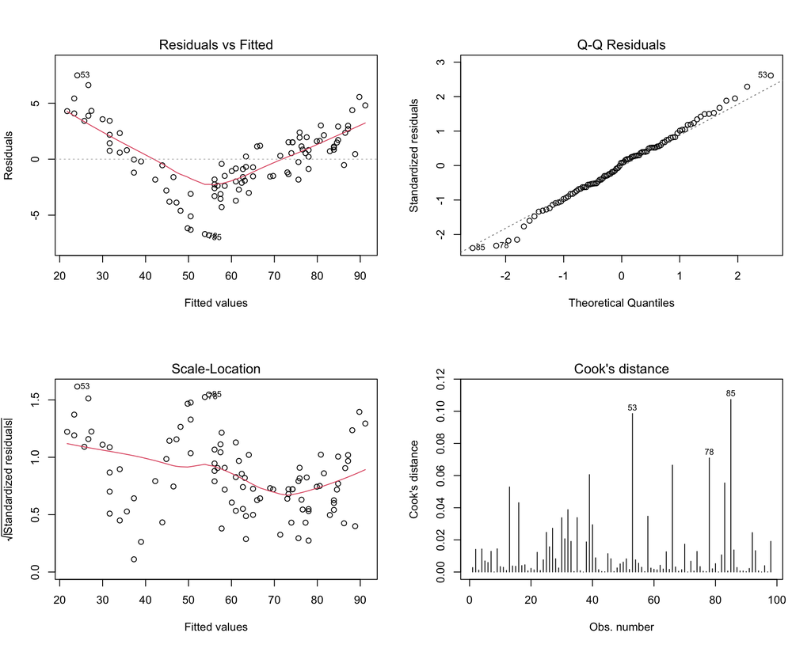

```r
# Base R diagnostic plots (Residuals vs Fitted, Q-Q, Scale-Location, Cook's D)
par(mfrow = c(2, 2))
plot(lm_af_main, which = 1:4)
```

```r
par(mfrow = c(1, 1))
```

The residuals vs fitted plot shows a U-shaped pattern, suggesting a violation of the linearity assumption. Variance also appears non-constant across the fitted range. Observations 53, 78, and 85 are flagged as potentially influential by Cook’s distance. The Q-Q plot is broadly acceptable, with minor deviations at the tails.

```r
# Variance Inflation Factors — check for multicollinearity among predictors
vif_af <- vif(lm_af_main)
cat("VIF values (AF model):\n")
```

```
## VIF values (AF model):
```

```r
print(round(vif_af, 3))
```

```
##            GVIF Df GVIF^(1/(2*Df))
## treatment 1.091  2           1.022
## age       1.120  1           1.058
## sex       1.055  1           1.027
```

```r
# VIF > 10 (or conservatively > 5) indicates a problematic level of collinearity
```

All GVIF^(1/(2·Df)) values are close to 1 (treatment: 1.022, age: 1.058, sex: 1.027), indicating no meaningful multicollinearity among predictors.